# Przykłady

Michał Burdukiewicz

10-12-2022

Źródło danych: https://github.com/michbur/polish-driver-license

## Rysunek 1

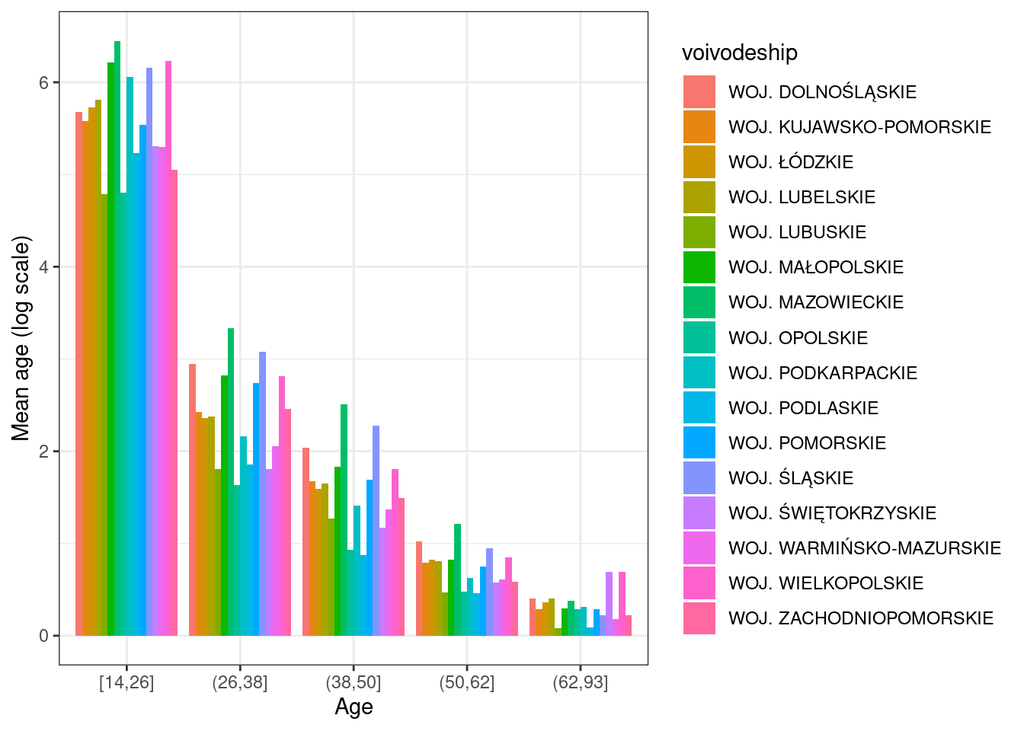

Cel: pokazanie średniej liczby osób, które uzyskały prawo jazdy w danym wieku w zależności od województwa.

## Rysunek 2

Atrybuty wizualne - oś X - wiek osób w podziale na stosowne grupy, oś Y - zlogarytmizowana liczba osób w danej grupie wiekowej.

Geometria - wykres słupkowy, dane zgrupowane w przedziałach co 5 lat,(Np. 18-22 , 23-28 itd.)

Fasety - 4 fasety każda prezentuje kolejny rok.

Statystyki - dane zlogarytmizowane.

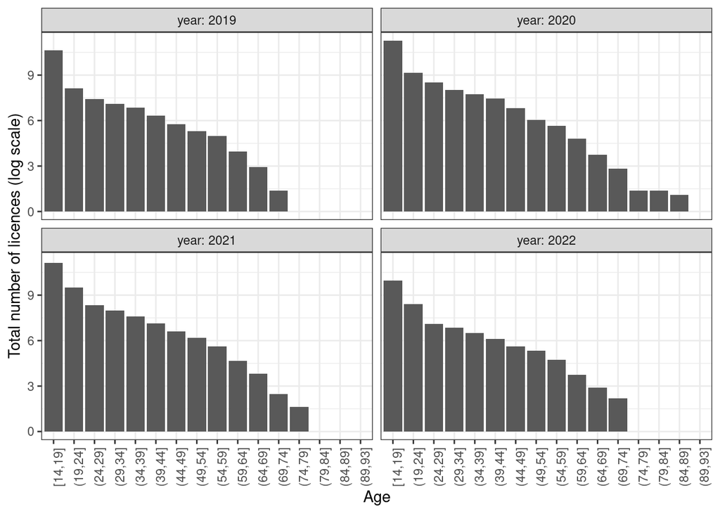

Cel: pokazanie liczby osób w danym wieku uzyskujących prawo jazdy w danym roku.

## Rysunek 3

- atrybutach wizualnych na osi X rok na osi Y miesiąc gradient intensywności koloru w zależności od liczby praw jazdy
- geometriach kafle
- facetach brak
- statystykach liczba uzyskanych praw jazdy

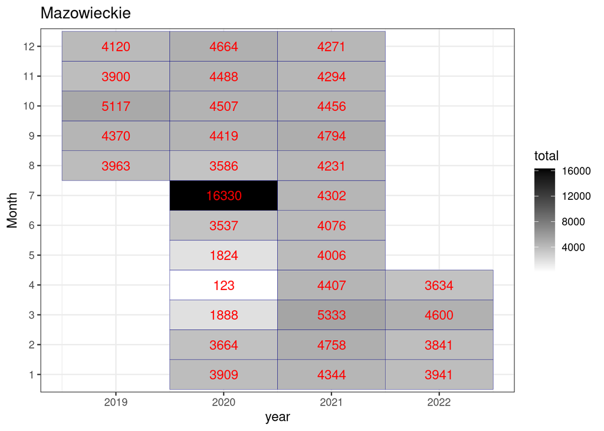

Cel: pokazanie zmienności liczby uzyskanych praw jazdy w skali roku w zależności od roku w województwie mazowieckim.

## Rysunek 4

- atrybutach wizualnych - wprowadzenie przezroczystosci punktow kolor(osobny kolor dla kobiet i osobny dla mężczyzn), wiek(na osi x), liczba uzyskanych praw jazdy(na osi y)
- geometriach - rozrożnienie kształtu w zależności od płci
- facetach - ewentualne wprowadzenie dwóch facet w podziale na płeć, lub może na grupy wiekowe
- statystykach liczba osób które uzyskały prawo jazdy w danym wieku, z podziałem na płec

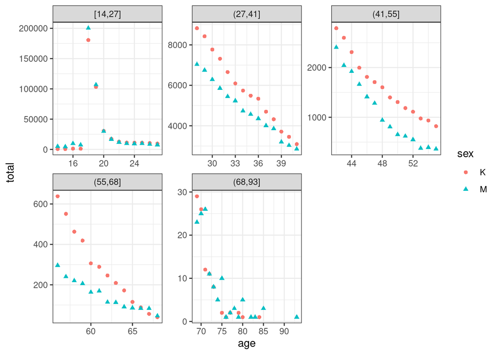

Cel: pokazać zależność liczby uzyskanych praw jazdy w zależności od wieku i płci.

## Rysunek 5

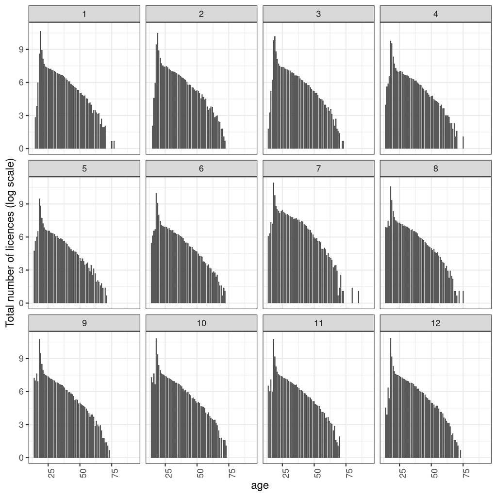

Cel: pokazać liczbę praw jazdy uzyskiwanych przez osoby w różnym wieku w zależności od miesiąca.

## Rysunek 6

- atrybutach wizualnych:
  - oś x - rok,
  - oś y - liczbę uzyskanych praw jazdy,
  - kolor słupka - płeć ( zielony - mężczyźni, czerwony - kobiety),
  - podział na 16 fasetów, po jednym dla województwa.
- geometriach:
  - zmiana wykresu na słupkowy, dodanie siatki
- facetach:
  - podział na województwa
- statystyka:
  - Suma uzyskanych praw jazdy dla poszczególnego województwa w zależności od płci i roku

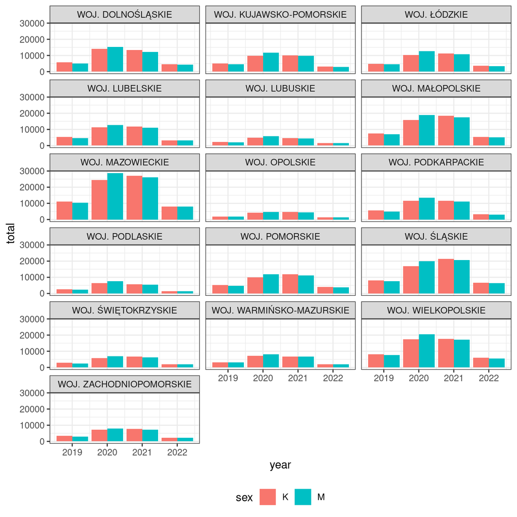

Cel: pokazać liczbę uzyskanych praw jazdy dla poszczególnych województw w zależności od płci i roku.